# LIONESS edges are quadratic functions of expression: closed forms, an interferon artifact, and equivalence with first-order features

Author

Authors are set by tools/authors.R before the final render

Published

November 12, 2026

**Draft.** This rendering is a draft: its numbers come from the run labeled below and will be replaced by the production run; highlighted numbers and markers are apparatus and are stripped in final mode.

**Status** (the drafting log’s opening line):

Status (revision 4, 2026-11-06): the paper test holds for a critique whose claims are the equivalence of LIONESS edges and their first-order features on a base with the gene levels (E1), the shared-factor artifact and its fix, and the effect of parametrization; the clinical answer (SLE against RA) waits on PRECISESADS access, and the run covers real data only through two small public datasets, GSE17755 and GSE326777.

The seven paper-test answers are in the drafting log.

# Abstract

**Background.** Single-sample network methods such as LIONESS give each patient a weight for every gene pair, read as that patient’s co-expression network, and these edges are compared between groups and used to classify patients. What an edge is made of has not been derived.

**Results.** The LIONESS edge of a Pearson correlation has an exact closed form and equals, to first order, the reference correlation plus the product of the patient’s two standardized expression values, minus a term in their squares. In a simulation of 25 settings, classifiers given the edges or this first-order formula, each added to a base holding an interferon score, its square, cell composition, and the gene levels, differed in AUC by -0.0066 to 0.0047 (MCSE at most 0.005). Interferon entered the edges as its square: without the squared score in the base, edges gained 0.033 (MCSE 0.011) in AUC at the largest interferon difference, and with it they added -0.007 to 0.005 (MCSE at most 0.006). With a true change in co-expression, edges gained 0.097 (MCSE 0.015), more than the same information entered as separate products and squares, by 0.068 (MCSE 0.008). In public lupus and rheumatoid arthritis series, exact and first-order edges correlated with a median of 0.9997 across gene pairs in sorted neutrophils and 0.976 in an array series with extreme values, and interferon-gene edges tracked the squared interferon score (median correlations 0.36 and 0.34).

**Conclusions.** A LIONESS edge is a quadratic function of the patient’s expression. A network claim should be checked against the first-order formula and against a base that holds the square of any shared factor, such as interferon.

# 1 Introduction

A correlation between two genes needs many samples, so the coordination of two genes in one patient cannot be read off that patient’s expression profile. Single-sample network methods were built to estimate it. LIONESS builds the network of all samples and the network without one sample, and interpolates between the two to give that sample’s network [1]. Its R implementation, lionessR, uses Pearson correlation by default [2]. The edges are then compared between patient groups or used as features to classify patients [2, 3]. In the paper that introduced lionessR, networks were computed for 53 osteosarcoma biopsies, and edges whose weights differed between patients with short and long metastasis-free survival were found with limma, to understand co-regulation differences between the groups [2]. Such a difference is read as a difference in how tightly two genes move together in the two groups.

In whole blood from patients with systemic lupus erythematosus (SLE) and rheumatoid arthritis (RA), one interferon program raises the expression of many genes together, to a degree that differs between the diseases [4]. What a LIONESS edge estimates under this condition follows from its form. Removing one sample is a rank-one change in the first and second moments, so the edge has a closed form in the sample’s standardized expression $z_{qi}$ and $z_{qj}$, and to first order it is the reference correlation plus the influence function of the correlation [5], $r + z_{qi} z_{qj} - \tfrac{r}{2}\left(z_{qi}^2 + z_{qj}^2\right)$. Two lines of earlier work come close. The LIONESS edge, $N r - (N - 1) r_{(-q)}$, has the form of the jackknife pseudo-value of the correlation [6, 7], and for per-sample changes in correlation against a large reference set the product $z_{qi} z_{qj}$ alone was derived [8]. Single-sample methods were also rewritten in common variables, the LIONESS edge as a background correlation plus a scaled change in correlation, and for the covariance used by BONOBO the change from removing one sample was shown, for large samples, to be the product of the sample’s deviations from the mean [9], and a near-linear relation between LIONESS and SSN edges [10] and higher LIONESS edge weights in the smaller of two subpopulations when two genes differ only in mean [9] were observed without a formula. None of these expressed the change in correlation, rather than in covariance, through the sample’s own standardized expression, where the standardization adds a term in the reference correlation. The exact form, its first-order term in the reference correlation, the square of a shared factor that it places in every edge between genes the factor moves, and what these mean for classification have not been derived.

This paper derives the exact LIONESS edge of a Pearson correlation and its first-order form, and asks three questions of a classifier whose base already holds the IFN score, its square, cell composition, and the gene levels. Do the exact edges and their first-order features give the same out-of-sample classification? When two classes differ in a shared factor such as interferon activity, how much do edges gain from its square, and does a reference model holding the square remove that gain? And why does the edge form detect a difference in co-expression that the same products and squares, entered as separate features, do not? A simulation study answers the three questions under controlled conditions, and two public series of SLE and RA patients check the first two findings in real blood. The full clinical comparison needs a larger cohort with measured cell composition [11]. TO CONFIRM: the application depends on access to the PRECISESADS data

# 2 Methods

## 2.1 The estimand and the procedure

A LIONESS edge is meant to estimate how strongly two genes are correlated in the population a sample comes from, using that sample alone. For a sample $q$ of a reference set of $N$ samples, LIONESS takes the Pearson correlation $r$ of genes $i$ and $j$ over all $N$ samples and the correlation $r_{(-q)}$ without the sample, and sets [1]

$$e_q = N r - (N - 1)\, r_{(-q)} .
\tag{1}$$

Write $z_{qi}$ for the expression of gene $i$ in sample $q$, standardized by the mean and standard deviation of the $N$ samples (divisor $N$), and $a = 1/(N - 1)$. Removing one sample is a rank-one change in the means and in the sums of squares and cross-products, so the correlation without the sample has a closed form, and the edge follows (Supplementary note S1.1):

$$\begin{aligned}
r_{(-q)} &= \frac{r - a\, z_{qi} z_{qj}}{\sqrt{\left(1 - a\, z_{qi}^2\right)\left(1 - a\, z_{qj}^2\right)}}, \\
e_q &= r + z_{qi} z_{qj} - \frac{r}{2}\left(z_{qi}^2 + z_{qj}^2\right) + O_p\left(N^{-1}\right).
\end{aligned}
\tag{2}$$

The leading terms of the second line, the first-order edge, are the reference correlation plus the influence function of the correlation at the sample [5] (note S1.2). They are a quadratic function of the sample’s own standardized expression. The product $z_{qi} z_{qj}$ alone is the single-sample correlation of iENA [8]; the term in $r$ is what LIONESS adds. A new sample is scored against a training set of size $N$ by adding it, with $b = 1/(N + 1)$ and $z$ standardized by the training set (note S1.3):

$$\begin{aligned}
r_{(+q)} &= \frac{r + b\, z_{qi} z_{qj}}{\sqrt{\left(1 + b\, z_{qi}^2\right)\left(1 + b\, z_{qj}^2\right)}}, \\
e_q &= (N + 1)\, r_{(+q)} - N r .
\end{aligned}
\tag{3}$$

For the partial correlation of two genes given a set of conditioning variables, the edge is computed in the same way from the partial correlations of the reference with and without the sample, each the correlation of the residuals of the two genes on the conditioning variables.

## 2.2 What the procedure estimates

When two genes both follow a shared factor $F$ with loadings $\lambda_i$ and $\lambda_j$, the conditional mean of their product is $\lambda_i \lambda_j F_q^2$, so the edge’s conditional mean is linear in the square of the factor (note S1.4):

$$\mathrm{E}\left[z_{qi} z_{qj} \mid F_q\right] = \lambda_i \lambda_j F_q^2 .
\tag{4}$$

An edge between two interferon-driven genes therefore carries the square of the interferon level. A classifier that holds the interferon score but not its square gains from edges whenever the classes differ in the distribution of the squared score, although the genes’ co-expression given the factor is the same in both classes.

When two classes differ only in the means of genes $i$ and $j$, by $\Delta_i$ and $\Delta_j$ overall standard deviations, and class 1 has share $\pi$, the class difference in mean edge is, to first order (note S1.5),

$$\mathrm{E}_1[e] - \mathrm{E}_0[e] \approx (1 - 2\pi) \left[\Delta_i \Delta_j - \frac{r}{2}\left(\Delta_i^2 + \Delta_j^2\right)\right],
\tag{5}$$

which is zero for balanced classes and grows with imbalance, with no change in co-expression.

## 2.3 The fix and the diagnostic

Two comparisons follow from Equation 2 and Equation 4. First, a classifier given the edges should be compared with one given the first-order edges, which a reader computes from the expression data in one line; if the two perform the same, a network result is a result about that quadratic function of expression. Second, the base model must hold the square of any factor in which the classes differ. We use a nested set of models built on one base, E1, which holds age, sex, cell composition, the interferon (IFN) score adjusted for composition, the squares of the score and of composition, and the gene levels.

## 2.4 Models and evaluation

All models classify one class against the other (Table 1). $R_0$ is a logistic regression on age, sex, composition, and the residual IFN score, the score’s residual on composition. $R_1$ adds the squared residual score and squared composition. E1 adds the genes of a gene set $G$. Four models add one feature set to E1: E5, the pairwise products and squares of the standardized genes; F1, the first-order edges; N1, the exact LIONESS edges; and N2, the LIONESS edges of the partial correlation given the IFN score and composition. E4 is a regularized discriminant analysis on the genes with composition and the score, the quadratic discriminant beside them. A ninth model, N1 with $R_0$, puts the LIONESS edges on $R_0$ alone, to show the interferon artifact. Every model with genes or edges is an elastic net [12] with the base terms unpenalized, so that genes and edges must earn their place; the penalty is chosen by inner five-fold cross-validation. Every derived quantity, including the standardization, the reference correlation, and the reference set of the edges, is computed inside each training fold, and test samples are scored by Equation 3.

Table 1: The models. Each model after E1 adds one penalized feature set to E1, so every comparison asks whether that set adds to a fixed base; N1 with the first base stands outside the nesting to show the interferon artifact. Composition is the cell composition; the IFN score is adjusted for composition.

| Model | Inputs | Role |
| --- | --- | --- |
| $R_0$ | Age, sex, composition, IFN score | The interferon base |
| $R_1$ | $R_0$ with the squared IFN score and squared composition | The base with the squared factor (the fix) |
| E1 | $R_1$ with the gene levels | The expression base of every model below it |
| E4 | Regularized discriminant analysis on the genes, composition, and the IFN score | The classical quadratic classifier |
| E5 | E1 with the pairwise products and squares of the standardized genes | The quadratic information as separate terms |
| F1 | E1 with the first-order edges | The first-order formula, the matched competitor |
| N1 | E1 with the LIONESS edges | The main network model |
| N2 | E1 with the partial-correlation LIONESS edges, given the IFN score and composition | The conditioned network |
| N1 with $R_0$ | $R_0$ with the LIONESS edges | The interferon artifact |

The contrasts are, for a model’s out-of-sample area under the ROC curve (AUC),

$$\begin{aligned}
\Delta_1 &= \mathrm{AUC}(\text{N1}) - \mathrm{AUC}(\text{E1}), \\
\Delta_2 &= \mathrm{AUC}(\text{N1}) - \mathrm{AUC}(\text{F1}), \\
A &= \mathrm{AUC}(\text{N1 with } R_0) - \mathrm{AUC}(R_0), \\
P &= \mathrm{AUC}(\text{N1}) - \mathrm{AUC}(\text{E5}).
\end{aligned}
\tag{6}$$

$\Delta_1$ asks whether edges add anything to the gene levels and the interferon terms, $\Delta_2$ whether they add anything to their own formula, $A$ how much they gain from interferon alone, and $P$ how much the edge form helps over the same quadratic information entered as separate terms. In data, $\Delta_1$ is tested for superiority with the corrected resampled $t$-test over repeated cross-validation [13], and the equivalence of edges and their formula is declared when the 90% interval of $\Delta_2$ lies inside $\pm 0.01$, the two one-sided tests [14].

## 2.5 Data

The simulation is described in the next section. The real-data checks use two public series from the Gene Expression Omnibus, each analysed on its own. GSE17755 holds two-colour array profiles of peripheral blood cells, as log2 ratios against a pooled healthy reference; we used the female patients with SLE or RA. GSE326777 holds RNA sequencing of sorted neutrophils from patients with SLE, RA, and Sjögren’s syndrome and healthy donors; we used the SLE and RA samples. The IFN score is the mean standardized expression of EPSTI1, IFI44L, LY6E, OAS3, and RSAD2, adapted from the IFN5 score, which sums their log2 expression [15]. Neither series records cell composition, and GSE326777 records no age or sex, so these terms are dropped there. The gene set is the 50 genes with the largest variance after regressing out the IFN score in the training fold, the score genes excluded. The application to the full question, untreated SLE against untreated RA in whole blood from the PRECISESADS cohort [11, 16], is planned under controlled access. TO CONFIRM: the PRECISESADS access request has not been submitted

## 2.6 Software and reproducibility

The code is organized as a research compendium [17]: an R package whose functions are documented and tested, analysis scripts that call those functions and write every result to a results folder, and this manuscript, which reads only from that folder, so that every number, table, and figure in it is computed from the saved results when the document is rendered. Each simulation cell has its own random seed, derived from the design table, and the per-replicate results are saved rather than summaries. The software and package versions used are recorded with the results.

The analysis used R 4.6.2 with glmnet 5.2; the session information of each run is saved with its results. TO CONFIRM: the repository URL for the paper

## 2.7 Use of AI

An AI assistant (Claude, Anthropic) was used to draft code, to propose the structure of the simulation study, to summarize literature, and to produce a first draft of the text. The authors reviewed, corrected, and take responsibility for every part of the manuscript. Every derivation was checked numerically, every function has a test, and every citation was checked against the cited record. No AI tool is an author, and no figure was generated by an AI tool.

# 3 Simulation study

## 3.1 Design

The simulation study is reported in the ADEMP structure [18]: aims, data-generating mechanisms, estimands, methods, and performance measures, with a Monte Carlo standard error for every reported rate and average.

The aims are the four questions above: whether N1 and F1 classify alike, how much edges gain from a shared factor and whether the base removes it, how much the edge form beats separate products and squares, and whether Equation 5 holds; with a fifth, the level and power of the tests applied to data. Each cohort has 50 genes. Genes 1 to 20 load 0.8 on an interferon factor $F$, the IFN score is the mean of the first five, genes 21 to 30 form a module with within-class correlation 0.3, and genes 31 to 50 load 0.4 on a composition factor; age and sex carry no class information. The gene set is the 45 genes outside the score. Study S1 checks Equation 5 in nine settings with a total of 400 samples. Study S2 varies one factor at a time around two base settings (Table 2): S2-A lets the classes differ only in the mean and spread of $F$, S2-B only in the module’s correlation. In seven test settings, each replicate runs the procedure used on real data: five repeats of five-fold cross-validation and the two tests. Each S2 replicate fits the nine models in an outer five-fold cross-validation and records the AUC of the pooled out-of-fold scores. Every contrast is reported with its Monte Carlo standard error (MCSE), and a difference is called nonzero only when it exceeds three MCSE.

Table 2: The settings of study S2. Each row varies one factor around its family’s base setting; $n$ is the size of class 1, the smaller class when its share is below one half; $\Delta\rho$ is the change in the module’s correlation in class 1; the IFN difference is the shift in the mean of the interferon factor and the ratio of its standard deviations in class 1.

| Family | Factor | Levels | Reason |
| --- | --- | --- | --- |
| S2-A, the interferon artifact | IFN difference | none, small, moderate, large, very large | From no difference to beyond any seen in the earlier runs |
| S2-A, the interferon artifact | score genes | 2, 5, 10 | The fix depends on how well the score measures the factor |
| S2-A, the interferon artifact | noise | normal, t5 | Outlying samples enlarge the remainder of the first-order form |
| S2-A, the interferon artifact | size of class 1, n | 40, 80, 150, 300 | From a small cohort to a large one |
| S2-B, equivalence and power | module change | 0, 0.1, 0.2, 0.3, 0.4 | From no co-expression difference, the null of the superiority test, to a large one |
| S2-B, equivalence and power | size of class 1, n | 40, 80, 150, 300 | Power and equivalence by size |
| S2-B, equivalence and power | share of class 1 | 0.5, 0.3, 0.15 | Imbalance, the condition of the mean-shift law |
| S2-B, equivalence and power | noise | normal, t5, t3 | Equivalence under heavy tails |
| S2-B, equivalence and power | elastic-net mixing | 0, 0.5, 1 | The parametrization effect is a property of the penalty |

## 3.2 Results

### 3.2.1 Edges and their first-order formula classified alike

In all 25 settings of study S2, the classifier given the LIONESS edges and the classifier given their first-order formula differed in AUC by -0.0066 to 0.0047 (MCSE at most 0.005) (Figure 1, purple points). This held where the edges carried no class information and where they carried the most, with heavy-tailed noise, at every sample size, and under ridge, elastic-net, and lasso penalties. The largest difference, -0.0066 (MCSE 0.005), came with noise from a $t$ distribution with three degrees of freedom, where the remainder of Equation 2 is largest.

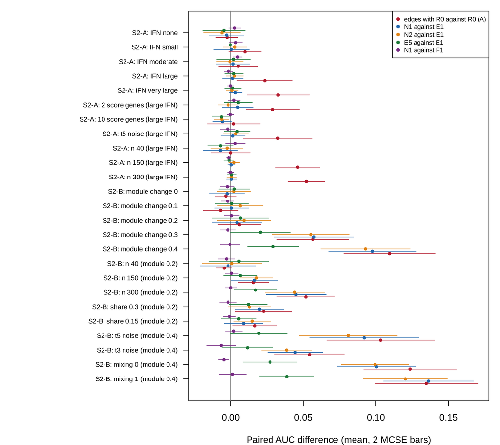

Figure 1: Paired differences in out-of-sample AUC in the settings of study S2, averaged over replicates, with bars of two Monte Carlo standard errors. Red: LIONESS edges on the base without the squared IFN score against that base, the interferon artifact $A$. Blue: edges added to E1 against E1, $\Delta_1$. Orange: partial-correlation edges added to E1 against E1. Green: products and squares added to E1 against E1. Purple: edges against their first-order formula, $\Delta_2$. The grey line is no difference. Each label names the factor varied and, in parentheses, the base setting.

### 3.2.2 Interferon entered the edges, and the base removed it

Edges gained from interferon alone, and the gain grew with the interferon difference. When the classes differed only in the interferon factor, edges added to the base without the squared score gained -0.003 (MCSE 0.004) with no difference, 0.023 (MCSE 0.010) at a large one, and 0.033 (MCSE 0.011) at the largest (Figure 1, red points). The gain also grew with the sample size, to 0.052 (MCSE 0.006) with 300 samples per class. On the base E1, which holds the squared score, the same edges added -0.007 to 0.005 (MCSE at most 0.006) across all 11 interferon settings (blue points), including the two-gene and ten-gene scores and heavy-tailed noise. The partial-correlation edges, which condition on the score, added -0.006 to 0.003 (MCSE at most 0.006) (orange points).

### 3.2.3 The edge form detected co-expression that separate terms missed

Edges found a true change in co-expression that the gene levels cannot show. When the module’s correlation differed between the classes, edges added to E1 gained up to 0.097 (MCSE 0.015) at a change of 0.4, and 0.057 (MCSE 0.014) at 0.3. The same quadratic information entered as separate products and squares gained 0.029 (MCSE 0.009) at 0.4 (green points), so the edge form beat it by 0.068 (MCSE 0.008); with a lasso penalty the gap was 0.098 (MCSE 0.010), and with a ridge penalty 0.073 (MCSE 0.008). The partial-correlation edges gained 0.093 (MCSE 0.015) at 0.4, and the regularized discriminant analysis 0.056 (MCSE 0.012) (Table 3). With no change in the module, edges added -0.003 to -0.003 (MCSE at most 0.006).

Table 3: Mean out-of-sample AUC of each model in the settings of study S2 with a change in co-expression, from the replicates of the run named in the banner. The largest Monte Carlo standard error of an entry is given below the table.

| Setting | R1 | E1 | E4 | E5 | F1 | N1 | N2 |
| --- | --- | --- | --- | --- | --- | --- | --- |
| S2-B: module change 0.1 | 0.498 | 0.495 | 0.492 | 0.496 | 0.498 | 0.496 | 0.501 |
| S2-B: module change 0.2 | 0.486 | 0.487 | 0.494 | 0.494 | 0.491 | 0.491 | 0.496 |
| S2-B: module change 0.3 | 0.502 | 0.504 | 0.568 | 0.525 | 0.564 | 0.562 | 0.559 |
| S2-B: module change 0.4 | 0.502 | 0.497 | 0.552 | 0.526 | 0.595 | 0.594 | 0.590 |
| S2-B: n 40 (module 0.2) | 0.523 | 0.519 | 0.492 | 0.525 | 0.520 | 0.517 | 0.520 |
| S2-B: n 150 (module 0.2) | 0.503 | 0.501 | 0.533 | 0.508 | 0.517 | 0.518 | 0.519 |
| S2-B: n 300 (module 0.2) | 0.500 | 0.501 | 0.522 | 0.518 | 0.546 | 0.546 | 0.545 |
| S2-B: share 0.3 (module 0.2) | 0.486 | 0.482 | 0.522 | 0.494 | 0.504 | 0.502 | 0.495 |
| S2-B: share 0.15 (module 0.2) | 0.460 | 0.463 | 0.537 | 0.468 | 0.473 | 0.472 | 0.478 |
| S2-B: t5 noise (module 0.4) | 0.505 | 0.508 | 0.564 | 0.527 | 0.597 | 0.600 | 0.589 |
| S2-B: t3 noise (module 0.4) | 0.493 | 0.497 | 0.554 | 0.508 | 0.548 | 0.541 | 0.535 |
| S2-B: mixing 0 (module 0.4) | 0.517 | 0.518 | 0.575 | 0.545 | 0.624 | 0.619 | 0.618 |
| S2-B: mixing 1 (module 0.4) | 0.476 | 0.473 | 0.587 | 0.512 | 0.608 | 0.610 | 0.594 |

The largest Monte Carlo standard error of an AUC in Table 3 is 0.022.

### 3.2.4 The tests applied to data

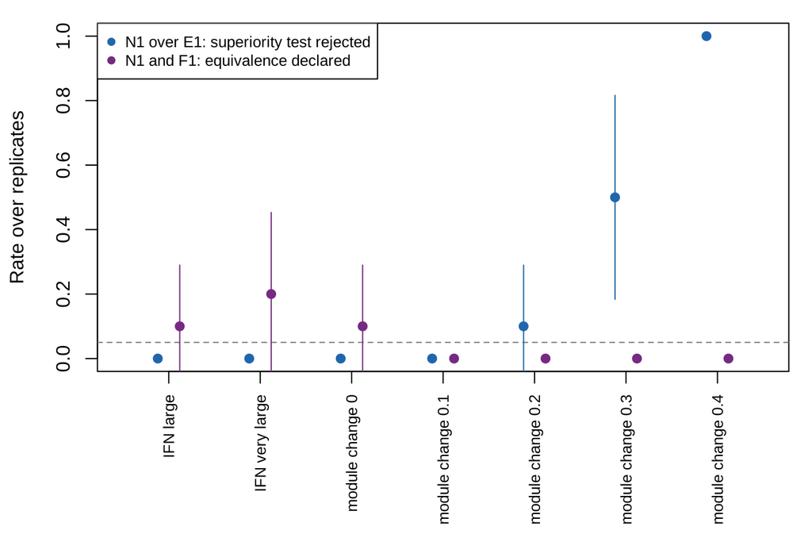

Figure 2: Rates of the two tests in the seven test settings, with bars of two Monte Carlo standard errors. Blue: the rate at which the corrected resampled $t$-test declared that LIONESS edges add to E1 (superiority of $\Delta_1$, one-sided at the 5% level). Purple: the rate at which the two one-sided tests declared edges and their first-order formula equivalent within $\pm 0.01$. The dashed line is 0.05.

### 3.2.5 The unequal-groups law held

In study S1, the class difference in mean edge under a pure mean shift matched Equation 5 in all nine settings: the observed minus the predicted difference ranged over -0.0051 to 0.0018 (MCSE at most 0.0055), while the predicted difference itself ranged from zero for balanced classes to 0.373 with a share of 0.15 and a shift of one standard deviation (Supplementary note S1.6).

# 4 Application

## 4.1 Data and comparison

The full question, untreated SLE against untreated RA in whole blood with measured cell composition, needs the PRECISESADS cohort [11], which is under controlled access and is not analysed here. TO CONFIRM: the PRECISESADS access request has not been submitted Two public series let us check, in real patients, the two findings that do not need a large sample: that edges equal their first-order formula, and that interferon enters the edges as its square. They are analysed as in the simulation, each on its own. GSE17755 gave 22 SLE and 93 RA patients and GSE326777 gave 34 SLE and 15 RA patients. Neither is large enough to estimate a small difference in AUC precisely, and the contrasts are reported with their corrected standard errors.

## 4.2 Edges followed their formula where values were not extreme, and interferon entered as its square

In the neutrophils of GSE326777, the exact LIONESS edge and its first-order formula correlated across samples with a median of 0.9997 over the 1,225 gene pairs of the gene set (smallest 0.9928). In GSE17755 the median was 0.9757, below the 0.99 we had set as the criterion, and some pairs agreed poorly (smallest -0.43). The two series differ in their extreme values: in GSE17755 the median gene of the gene set had a sample 9.3 standard deviations from its mean, against 2.3 in GSE326777, and pairs with a more extreme value agreed less with their formula (Spearman correlation -0.47 in GSE17755 and -0.75 in GSE326777). TO CONFIRM: this comparison was added after the planned checks, as an explanation; it agrees with the remainder of Equation 2 growing with the fourth power of a standardized value For the ten pairs of interferon-score genes, the edge correlated with the squared centred IFN score with a median of 0.36 in GSE17755 and 0.34 in GSE326777, above the 0.3 we had set.

In classification (Table 4), the IFN score alone already separated the diseases, with an AUC of 0.942 in GSE17755 and 0.836 in GSE326777. Edges and their first-order formula differed by less than 0.01 in AUC in all four analyses, but with these sample sizes the 90% intervals were wider than the margin, so equivalence was not declared. Neither edges nor any other added feature set improved on E1 beyond its standard error, and the interferon artifact $A$ was within its standard error of zero. In GSE17755 the gene levels alone reached an AUC of 0.991, which leaves little room for any added feature. TO CONFIRM: such near-perfect separation by gene levels suggests that disease and processing are confounded in GSE17755

To look for the artifact where interferon does not decide the comparison, each series was restricted to the patients whose IFN score lay within the range of the other disease’s scores, each series still analysed on its own. The subsets held 9 SLE and 23 RA patients and 13 SLE and 7 RA patients. In GSE17755 the IFN score alone separated the diseases less well than before (AUC 0.766), and the artifact $A$ was 0.007 (standard error 0.025), within its standard error of zero. In GSE326777 every model scored below an AUC of one half, so twenty patients were too few for any classifier to learn from, and that subset is not informative (Table 4).

Table 4: Contrasts in the two public series, as means over 20 repeats of five-fold cross-validation, with standard errors corrected for the overlap of training sets; for $\Delta_2$, the 90% interval. $A$: LIONESS edges on the base without the squared score against that base. $\Delta_1$: N1 against E1. $\Delta_2$: N1 against F1. $P$: N1 against E5. The sensitivity analyses keep, in GSE17755, the SLE samples submitted with the RA samples and, in GSE326777, the samples without an N suffix; the overlapping-IFN analyses keep the patients whose IFN score lies within the range of the other disease. Each series is analysed on its own.

| Series | Analysis | SLE, RA | AUC of E1 | A | Delta 1 | Delta 2 (90% interval) | P |
| --- | --- | --- | --- | --- | --- | --- | --- |
| GSE17755 | primary | 22, 93 | 0.991 | 0.006 (0.011) | -0.014 (0.011) | -0.003 (-0.018 to 0.012) | -0.002 (0.012) |
| GSE17755 | same submission date | 12, 93 | 0.978 | 0.009 (0.014) | -0.010 (0.013) | 0.004 (-0.019 to 0.027) | -0.005 (0.013) |
| GSE326777 | primary | 34, 15 | 0.805 | -0.001 (0.008) | 0.017 (0.031) | -0.001 (-0.014 to 0.013) | -0.002 (0.009) |
| GSE326777 | no N suffix | 23, 15 | 0.824 | -0.000 (0.012) | -0.016 (0.033) | 0.001 (-0.015 to 0.017) | -0.002 (0.012) |
| GSE17755 | overlapping IFN | 9, 23 | 0.942 | 0.007 (0.025) | -0.087 (0.070) | -0.002 (-0.073 to 0.070) | 0.065 (0.067) |
| GSE326777 | overlapping IFN | 13, 7 | 0.300 | -0.025 (0.080) | -0.023 (0.125) | -0.037 (-0.171 to 0.097) | 0.000 (0.098) |

# 5 Discussion

A LIONESS edge of a Pearson correlation is, to first order, the reference correlation plus the product of the sample’s two standardized values, minus a term in their squares (Equation 2). Three consequences followed in simulation. A classifier given the edges and one given their first-order formula reached the same AUC in every setting, so a network result is reproduced, and explained, without building a network. Interferon entered the edges as its square, so edges gained over a base that held the interferon score but not its square, and a base that held the square removed the gain. And when co-expression truly differed, the edge form found it where the same quadratic information, entered as separate products and squares, found much less.

For a user, this gives two checks that any network claim should pass. The first is the formula: if the first-order edges, computed from the expression data in one line, do as well as the edges, the claim is about a quadratic function of expression, and it should be described as such. The second is the base: any factor that moves many genes and differs between the groups, interferon in SLE and RA or cell composition in blood, should enter the base with its square. A third caution concerns group comparisons of mean edges: when the groups are unequal in size, a difference in gene means alone shifts the mean edge in proportion to $(1 - 2\pi)$ (Equation 5), with no change in co-expression. Other single-sample methods share the structure: the SSN edge is the rescaled change in correlation when the sample is added to a reference set [19], iENA’s single-sample correlation is the product term alone [8], SWEET’s edge is a weighted add-one change [20], and BONOBO’s is the correlation of a covariance updated with the sample’s own deviation [21], so each is a function of the sample’s own deviations and the same two checks apply.

The edge form helped because of the penalty, not because of new information. The first-order edges are a fixed linear combination of the products and squares, and a penalized classifier given that combination spends one coefficient on it, while one given the terms separately must find the combination itself at a higher cost in penalty; the advantage was present under ridge, elastic-net, and lasso penalties (Figure 1). The tests applied to data held their level where edges add nothing to E1, and gained power as the change in co-expression grew (Figure 2). Equivalence of edges and their formula, however, was declared in at most 0.20 of the replicates at 80 samples per class, although the two differed by little: with that sample size, a margin of 0.01 in AUC is narrower than the precision of repeated cross-validation, so an equivalence claim in data needs a larger cohort or a wider margin.

Table 5: What was known and what this paper adds.

[output not shown]

The study has limits. The simulation used one interferon factor with equal loadings, one composition factor observed without error, and a fixed gene set, so the size of the artifact in blood, where several factors with unequal loadings act at once, is not known from it. The real-data checks used two small public series, without measured composition. In GSE17755 the first-order formula fitted less closely, where single samples took extreme values; a user with such data should compute the exact edges or screen out genes whose variance rests on one sample. GSE17755 also showed signs that disease and processing were confounded. The clinical question, whether LIONESS edges add information to the gene levels and the interferon terms when classifying SLE against RA, needs the larger PRECISESADS cohort, and its answer is not given here. Table 5 sets what was known beside what this paper adds.

Several extensions lie outside this paper: the formula-based comparison for the other single-sample methods fitted as classifiers, a corrected single-sample network method, other pairs of autoimmune diseases, and the use of edges in a clinical classifier.

# Availability of data and materials

The public series analysed are GSE17755 and GSE326777 in the Gene Expression Omnibus; the PRECISESADS data are available from ELIXIR Luxembourg under controlled access (dataset ELU-2-E592B0-1) [16]. The code, the simulation results, and this manuscript are organized as a research compendium [17]. TO CONFIRM: the public repository URL

# References

1. Kuijjer ML, Tung MG, Yuan G, Quackenbush J, Glass K. Estimating sample-specific regulatory networks. iScience. 2019;14:226–40. https://doi.org/10.1016/j.isci.2019.03.021.

2. Kuijjer ML, Hsieh P-H, Quackenbush J, Glass K. lionessR: Single sample network inference in R. BMC Cancer. 2019;19:1003. https://doi.org/10.1186/s12885-019-6235-7.

3. Jahagirdar S, Saccenti E. Evaluation of single sample network inference methods for metabolomics-based systems medicine. Journal of Proteome Research. 2021;20:932–49. https://doi.org/10.1021/acs.jproteome.0c00696.

4. El-Sherbiny YM, Psarras A, Md Yusof MY, Hensor EMA, Tooze R, Doody G, et al. A novel two-score system for interferon status segregates autoimmune diseases and correlates with clinical features. Scientific Reports. 2018;8:5793. https://doi.org/10.1038/s41598-018-24198-1.

5. Devlin SJ, Gnanadesikan R, Kettenring JR. Robust estimation and outlier detection with correlation coefficients. Biometrika. 1975;62:531–45. https://doi.org/10.1093/biomet/62.3.531.

6. Quenouille MH. Notes on bias in estimation. Biometrika. 1956;43:353–60. https://doi.org/10.1093/biomet/43.3-4.353.

7. Miller RG. The jackknife: A review. Biometrika. 1974;61:1–15. https://doi.org/10.1093/biomet/61.1.1.

8. Yu X, Zhang J, Sun S, Zhou X, Zeng T, Chen L. Individual-specific edge-network analysis for disease prediction. Nucleic Acids Research. 2017;45:e170. https://doi.org/10.1093/nar/gkx787.

9. Kuijjer M, De Marzio M, Glass K. Challenges and opportunities in single-sample network modeling. 2026. https://doi.org/10.64898/2026.02.27.708608.

10. Deschildre J, Vandemoortele B, Loers JU, De Preter K, Vermeirssen V. Evaluation of single-sample network inference methods for precision oncology. npj Systems Biology and Applications. 2024;10:18. https://doi.org/10.1038/s41540-024-00340-w.

11. Barturen G, Babaei S, Català-Moll F, et al. Integrative analysis reveals a molecular stratification of systemic autoimmune diseases. Arthritis & Rheumatology. 2021;73:1073–85. https://doi.org/10.1002/art.41610.

12. Friedman J, Hastie T, Tibshirani R. Regularization paths for generalized linear models via coordinate descent. Journal of Statistical Software. 2010;33. https://doi.org/10.18637/jss.v033.i01.

13. Nadeau C, Bengio Y. Inference for the generalization error. Machine Learning. 2003;52:239–81. https://doi.org/10.1023/A:1024068626366.

14. Schuirmann DJ. A comparison of the two one-sided tests procedure and the power approach for assessing the equivalence of average bioavailability. Journal of Pharmacokinetics and Biopharmaceutics. 1987;15:657–80. https://doi.org/10.1007/BF01068419.

15. Mai L, Asaduzzaman A, Noamani B, Fortin PR, Gladman DD, Touma Z, et al. The baseline interferon signature predicts disease severity over the subsequent 5 years in systemic lupus erythematosus. Arthritis Research & Therapy. 2021;23:29. https://doi.org/10.1186/s13075-021-02414-0.

16. ELIXIR Luxembourg. PRECISESADS: Cross sectional study & inception cohort data (V1.0). 2017. https://doi.org/10.17881/th9v-xt85.

17. Marwick B, Boettiger C, Mullen L. Packaging data analytical work reproducibly using R (and friends). The American Statistician. 2018;72:80–8. https://doi.org/10.1080/00031305.2017.1375986.

18. Morris TP, White IR, Crowther MJ. Using simulation studies to evaluate statistical methods. Statistics in Medicine. 2019;38:2074–102. https://doi.org/10.1002/sim.8086.

19. Liu X, Wang Y, Ji H, Aihara K, Chen L. Personalized characterization of diseases using sample-specific networks. Nucleic Acids Research. 2016;44:e164. https://doi.org/10.1093/nar/gkw772.

20. Chen HH, Hsueh CW, Lee CH, Hao TY, Tu TY, Chang LY, et al. SWEET: A single-sample network inference method for deciphering individual features in disease. Briefings in Bioinformatics. 2023;24. https://doi.org/10.1093/bib/bbad032.

21. Saha E, Fanfani V, Mandros P, Ben Guebila M, Fischer J, Shutta KH, et al. Bayesian inference of sample-specific coexpression networks. Genome Research. 2024;34:1397–410. https://doi.org/10.1101/gr.279117.124.

# Supplementary note S1

This note derives the closed forms the paper relies on: the exact LIONESS edge of a Pearson correlation, its first-order form, the add-one form used to score new samples, the conditional expectation of an edge under a shared factor, and the class difference in mean edge under a pure mean shift. Each derivation uses only the first and second sample moments, so each is checked against a direct computation.

Notation. Sample $q$ of $N$; genes $i$ and $j$; $\bar x_i$ and $s_i$ the mean and standard deviation of gene $i$ over all $N$ samples (divisor $N$); $z_{qi} = (x_{qi} - \bar x_i)/s_i$; $r$ the Pearson correlation of genes $i$ and $j$ over all $N$ samples; $a = 1/(N - 1)$ and $b = 1/(N + 1)$.

### S1.1 The exact LIONESS edge

The correlation without sample $q$ is

$$r_{(-q)} = \frac{r - a\, z_{qi} z_{qj}}{\sqrt{\left(1 - a\, z_{qi}^2\right)\left(1 - a\, z_{qj}^2\right)}} .$$

Write $S_{ij} = \sum_p (x_{pi} - \bar x_i)(x_{pj} - \bar x_j) = N s_i s_j r$ and $d_{qi} = x_{qi} - \bar x_i = s_i z_{qi}$. Removing sample $q$ changes the mean to $\bar x_i - d_{qi}/(N - 1)$, and the cross-product about the new mean is

$$\begin{aligned}
S_{ij}^{(-q)} &= S_{ij} - \frac{N}{N - 1}\, d_{qi} d_{qj} \\
&= N s_i s_j \left(r - a\, z_{qi} z_{qj}\right),
\end{aligned}$$

and in the same way $S_{ii}^{(-q)} = N s_i^2 \left(1 - a\, z_{qi}^2\right)$. Line 1 is the downdate of a sum of squares and cross-products by one observation; line 2 substitutes $d_{qi} = s_i z_{qi}$ and $N/(N - 1) = N a$. The ratio $S_{ij}^{(-q)} / \sqrt{S_{ii}^{(-q)} S_{jj}^{(-q)}}$ gives the display. The LIONESS edge is $e_q = N r - (N - 1)\, r_{(-q)}$. The paper uses this form for every training edge; `tests/testthat/test-lioness.R` checks it against leave-one-out refits to $10^{-12}$.

### S1.2 The first-order edge

$$\begin{aligned}
r_{(-q)} &= \left(r - a\, z_{qi} z_{qj}\right)\left(1 + \tfrac{a}{2}\left(z_{qi}^2 + z_{qj}^2\right) + O_p\left(a^2\right)\right) \\
&= r - a\, z_{qi} z_{qj} + \tfrac{a r}{2}\left(z_{qi}^2 + z_{qj}^2\right) + O_p\left(a^2\right), \\
e_q &= N r - (N - 1)\, r_{(-q)} \\
&= r + z_{qi} z_{qj} - \tfrac{r}{2}\left(z_{qi}^2 + z_{qj}^2\right) + O_p\left(N^{-1}\right).
\end{aligned}$$

Line 1 expands each factor $(1 - a z^2)^{-1/2} = 1 + \tfrac{a}{2} z^2 + O(a^2)$, which holds because $z_{qi}$ is $O_p(1)$ and $a \to 0$. Line 2 multiplies out. Line 3 is the definition, and line 4 substitutes line 2 and uses $(N - 1) a = 1$ and $(N - 1) O_p(a^2) = O_p(N^{-1})$. The leading terms are the reference correlation plus the influence function of the correlation at the sample [5]. The edge has the form of the jackknife pseudo-value of the correlation [6, 7], and this derivation shows that, for the correlation, its first-order form is the influence function. The paper uses this form as the features of model F1; `tests/testthat/test-lioness.R` checks that the remainder shrinks as $N$ grows.

### S1.3 The add-one edge for a new sample

For a new sample standardized by the reference mean and standard deviation, adding it to the $N$ reference samples gives

$$\begin{aligned}
S_{ij}^{(+q)} &= S_{ij} + \frac{N}{N + 1}\, d_{qi} d_{qj} = N s_i s_j \left(r + b\, z_{qi} z_{qj}\right), \\
r_{(+q)} &= \frac{r + b\, z_{qi} z_{qj}}{\sqrt{\left(1 + b\, z_{qi}^2\right)\left(1 + b\, z_{qj}^2\right)}}, \\
e_q &= (N + 1)\, r_{(+q)} - N r .
\end{aligned}$$

Line 1 is the update of a sum of cross-products by one observation, line 2 the ratio, and line 3 the LIONESS edge of a sample added to the reference. A test sample never enters its training reference, so cross-validated performance is not inflated. The paper uses this form for every test edge; `tests/testthat/test-lioness.R` checks it against direct computation.

### S1.4 An edge under a shared factor

Let $z_{qi} = \lambda_i F_q + \varepsilon_{qi}$, with the factor $F_q$ and the noise terms independent, and the noise of different genes independent. Then, for $i \ne j$,

$$\begin{aligned}
\mathrm{E}\left[z_{qi} z_{qj} \mid F_q\right] &= \lambda_i \lambda_j F_q^2, \\
\mathrm{E}\left[e_q \mid F_q\right] &= r + \lambda_i \lambda_j F_q^2 - \tfrac{r}{2}\left(\lambda_i^2 + \lambda_j^2\right) F_q^2 - \tfrac{r}{2}\left(\sigma_i^2 + \sigma_j^2\right) + O\left(N^{-1}\right),
\end{aligned}$$

where $\sigma_i^2$ is the noise variance of gene $i$. Line 1 holds because the cross terms have mean zero; line 2 substitutes it into S1.2. The edge’s conditional mean is linear in $F_q^2$, so a classifier that holds $F$ but not $F^2$ gains from edges whenever the classes differ in the distribution of $F^2$. The paper’s base models $R_1$ and E1 hold the squared score.

### S1.5 The class difference in mean edge under a mean shift

Let class 1 have share $\pi$ and differ from class 0 only in the means of genes $i$ and $j$, by $\Delta_i$ and $\Delta_j$ in units of the overall standard deviation, with the same within-class covariance. The overall mean of $z_{qi}$ is zero, so its class means are $(1 - \pi)\Delta_i$ and $-\pi \Delta_i$. To first order,

$$\begin{aligned}
\mathrm{E}_1[e] - \mathrm{E}_0[e] &\approx \left[(1 - \pi)^2 - \pi^2\right] \left[\Delta_i \Delta_j - \tfrac{r}{2}\left(\Delta_i^2 + \Delta_j^2\right)\right] \\
&= (1 - 2\pi) \left[\Delta_i \Delta_j - \tfrac{r}{2}\left(\Delta_i^2 + \Delta_j^2\right)\right].
\end{aligned}$$

Line 1 applies S1.2 in each class: the within-class second moments are equal and cancel, and each product or square of class means contributes its class’s mean shift. Line 2 uses $(1 - \pi)^2 - \pi^2 = 1 - 2\pi$. The difference is zero for balanced classes and grows with imbalance, with no change in co-expression. The paper’s study S1 checks it against the simulated difference (`MeanShiftEdgeDifference()`).

### S1.6 The unequal-groups law in study S1

Table S1 gives, for each setting of study S1, the class difference in mean LIONESS edge over the 45 pairs of the module, the difference that Equation 5 predicts, and their gap with its Monte Carlo standard error.

| Share of class 1 | Mean shift (SD) | Observed | Predicted | Gap |
| --- | --- | --- | --- | --- |
| 0.50 | 0.25 | -0.0031 | 0.0000 | -0.0031 (0.0040) |
| 0.30 | 0.25 | 0.0154 | 0.0177 | -0.0023 (0.0037) |
| 0.15 | 0.25 | 0.0244 | 0.0295 | -0.0051 (0.0055) |
| 0.50 | 0.5 | 0.0018 | 0.0000 | 0.0018 (0.0035) |
| 0.30 | 0.5 | 0.0598 | 0.0627 | -0.0029 (0.0037) |
| 0.15 | 0.5 | 0.1148 | 0.1137 | 0.0011 (0.0046) |
| 0.50 | 1 | 0.0002 | 0.0000 | 0.0002 (0.0027) |
| 0.30 | 1 | 0.1915 | 0.1920 | -0.0005 (0.0027) |
| 0.15 | 1 | 0.3705 | 0.3731 | -0.0026 (0.0040) |

Table S1: The class difference in mean LIONESS edge under a pure mean shift in study S1: observed, predicted by Equation 5, and their gap (Monte Carlo standard error), with a total of 400 samples per cohort.

**Gap table.** One row per figure or table: the run and size behind it now, against the production run that replaces it.

| Output | What it shows | Run | Cells and replicates now | Production run | Monte Carlo error |
| --- | --- | --- | --- | --- | --- |
| fig-contrasts | paired AUC differences in the S2 settings | quick | 25 cells, 20 replicates | 25 settings, 400 replicates each |  |
| tbl-auc | mean AUC by model, S2-B settings | quick | 13 cells, 20 replicates | 400 replicates each |  |
| fig-tests | rejection and equivalence rates | quick | 7 cells, 10 replicates | 7 settings, 300 replicates each |  |
| stbl-s1 | S1 observed and predicted mean-edge differences | quick | 9 cells, 100 replicates | 9 settings, 1,000 replicates each |  |

**Markers.** Every decision still open and every claim without a usable source, with its section.

| Marker | Text | Section |
| --- | --- | --- |
| TO CONFIRM | the application depends on access to the PRECISESADS data | Introduction |
| TO CONFIRM | the PRECISESADS access request has not been submitted | Data |
| TO CONFIRM | the repository URL for the paper | Software and reproducibility |
| TO CONFIRM | the PRECISESADS access request has not been submitted | Data and comparison |
| TO CONFIRM | this comparison was added after the planned checks, as an explanation; it agrees with the remainder of Equation 2 growing with the fourth power of a standardized value | Edges followed their formula where values were not extreme, and interferon entered as its square |
| TO CONFIRM | such near-perfect separation by gene levels suggests that disease and processing are confounded in GSE17755 | Edges followed their formula where values were not extreme, and interferon entered as its square |
| TO CONFIRM | the public repository URL | Availability of data and materials |